# Real life example

Hugo Gruson

2024-03-21

```r
library(lightr)
```

This vignette has two goals:

- demonstrate that `lightr` parsers produce the same output as the official software
- show an example of analysis you can run once you’ve imported your data with `lightr`

For this, we use spectral data of the beak of the [atlantic puffin, *Fratercula arctica*](https://en.wikipedia.org/wiki/Atlantic_puffin). This data was collected by Dr Claire Doutrelant, using an OceanOptics spectrometer.

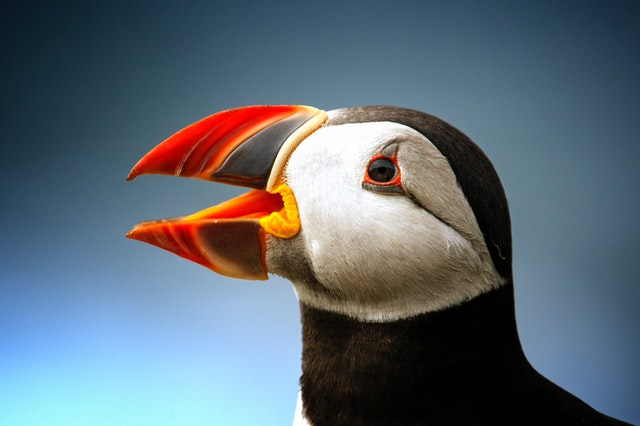

Atlantic puffin close up, by user john-289283 from pexels.com

```r
knitr::include_graphics("puffin-small.jpg")
```

# Comparison of outputs

By default, OceanInsight spectrometers produce `.ProcSpec` files, which R cannot readily import. To help with this, OceanInsight official software, SpectraSuite has a conversion feature, which turns `.ProcSpec` files into tab separated values files (`.txt`).

So, let’s start by comparing the `.ProcSpec` spectra imported by `lightr` and the `.txt` files produced by OceanOptics.

```r
raw_files <- lr_get_spec(file.path("data", "puffin"), ext = "ProcSpec")
```

```
#> 2 files found; importing spectra:
```

```r
txt_files <- lr_get_spec(file.path("data", "puffin"), ext = "txt")
```

```
#> 2 files found; importing spectra:
```

We can visually inspect these two file using the dedicated S3 function `pavo::plot.rspec()`:

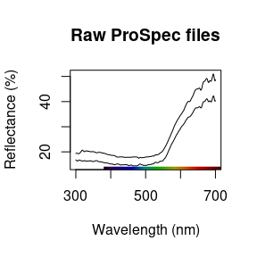

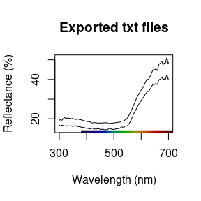

```r
library(pavo)
plot(raw_files, main = "Raw ProSpec files")
plot(txt_files, main = "Exported txt files")
```

Spectra imported by `lightr` and converted by SpectraSuite look pretty similar upon visual inspection and we can confirm this with

```r
all.equal(raw_files, txt_files, tol = 1e-4)
```

```
#> [1] TRUE
```

# Example of analysis

For this, we will look at the difference in hue and brightness on the red part of the beak for two individuals, with `pavo::summary.rspec()` function (after smoothing with `pavo::procspec()`):

```r
beak <- procspec(raw_files, opt = "smooth")
```

```
#> processing options applied:
#> smoothing spectra with a span of 0.25
```

```r
summary(beak, subset = c("B2", "H5"))
```

```
#>                 B2  H5
#> BR_PF26_1 26.23823 569
#> BR_PF27_3 21.78785 581
```

Okay, these two individuals seem to differ quite a lot in terms of hue and brightness. Now, one might ask if these difference can be perceived in bird vision. We can test this with the `pavo::coldist()` function.

```r
vis_beak <- vismodel(beak, visual = "avg.uv", achromatic = "ch.dc")
tcs_beak <- colspace(vis_beak)
coldist(tcs_beak, achromatic = TRUE)
```

```
#> Quantum catch are relative, distances may not be meaningful
#> Calculating unweighted Euclidean distances and Weber luminance contrast
#>      patch1    patch2          dS        dL
#> 1 BR_PF26_1 BR_PF27_3 0.005867583 0.2004935
```

The values of `dS` and `dL` are below the 1 JND ([just noticeable differences](https://en.wikipedia.org/wiki/Just-noticeable_difference)) threshold, which means that the colour of the two individuals, in spite of their difference, looks the same to the birds.